# EDA Top Tracks

Ixchel Peralta-martinez

```r
suppressPackageStartupMessages({
library(tidyverse);
library(ggplot2);
library(RColorBrewer);
library(MASS);
library(knitr);
library(kableExtra);
library(RColorBrewer);
library("papeR");
library(readxl)
myPalette <- brewer.pal(8, "Set2") })
```

```r
Songs <- read_xlsx(path = "Data/Top_2000_Songs_Dataset.xlsx")
head(Songs)
```

```
## # A tibble: 6 × 15
##   Index Title             Artist `Top Genre`  Year Beats Per Minute (BP…¹ Energy
##   <dbl> <chr>             <chr>  <chr>       <dbl>                  <dbl>  <dbl>
## 1  1794 Sacrifice         Anouk  dutch indie  1998                    136     17
## 2   774 Hou Vol Hou Vast  BLØF   dutch pop    2018                     86     61
## 3   625 Three Days In A … Anouk  dutch indie  2015                    171     50
## 4   412 Peter Gunn Theme  Emers… album rock   2010                    131     83
## 5   606 Het Dorp - Live   Wim S… dutch caba…  2015                    114     44
## 6   754 Malle Babbe       Rob D… dutch pop    2018                     87     38
## # ℹ abbreviated name: ¹`Beats Per Minute (BPM)`
## # ℹ 8 more variables: Danceability <dbl>, `Loudness (dB)` <dbl>,
## #   Liveness <dbl>, Valence <dbl>, `Length (Duration)` <dbl>,
## #   Acousticness <dbl>, Speechiness <dbl>, Popularity <dbl>
```

```r
Numsongs = Songs[,6:15]#keep numeric vars
colSums(is.na(Numsongs))# check if any column has misssing variable
```

```
## Beats Per Minute (BPM)                 Energy           Danceability
##                      0                      0                      0
##          Loudness (dB)               Liveness                Valence
##                      0                      0                      0
##      Length (Duration)           Acousticness            Speechiness
##                      0                      0                      0
##             Popularity
##                      0
```

```r
head(Numsongs)
```

```
## # A tibble: 6 × 10
##   `Beats Per Minute (BPM)` Energy Danceability `Loudness (dB)` Liveness Valence
##                      <dbl>  <dbl>        <dbl>           <dbl>    <dbl>   <dbl>
## 1                      136     17           54             -13        9      24
## 2                       86     61           51              -5        8      23
## 3                      171     50           36              -6       16      39
## 4                      131     83           43              -7       92      71
## 5                      114     44           37             -15       67      45
## 6                       87     38           35             -10       12      53
## # ℹ 4 more variables: `Length (Duration)` <dbl>, Acousticness <dbl>,
## #   Speechiness <dbl>, Popularity <dbl>
```

```r
Numsongs2=Numsongs %>%
  rename(
    BPM = "Beats Per Minute (BPM)",
    dB = "Loudness (dB)",Duration = "Length (Duration)"
    ) # rename columns
```

```r
Numsongs2$Duration=as.integer(gsub(",", "", Numsongs2$Duration))# find any commas remove them change char into integer
colSums(is.na(Numsongs2))#check make sure no missing values
```

```
##          BPM       Energy Danceability           dB     Liveness      Valence
##            0            0            0            0            0            0
##     Duration Acousticness  Speechiness   Popularity
##            0            0            0            0
```

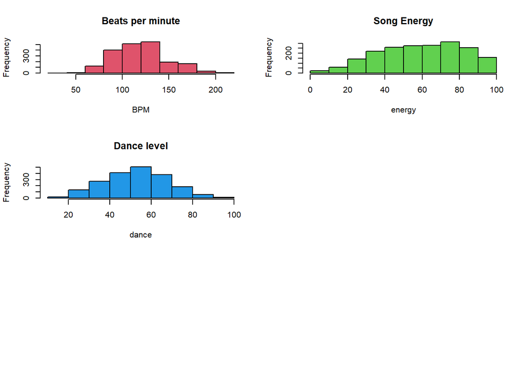

```r
par(mfrow=c(3,2))
hist(Numsongs2$BPM, main = "Beats per minute", xlab = "BPM", ylab= "Frequency",col=2)
hist(Numsongs2$Energy, main = "Song Energy", xlab = "energy", ylab= "Frequency",col=3)
hist(Numsongs2$Danceability, main = "Dance level", xlab = "dance", ylab= "Frequency",col=4)
```

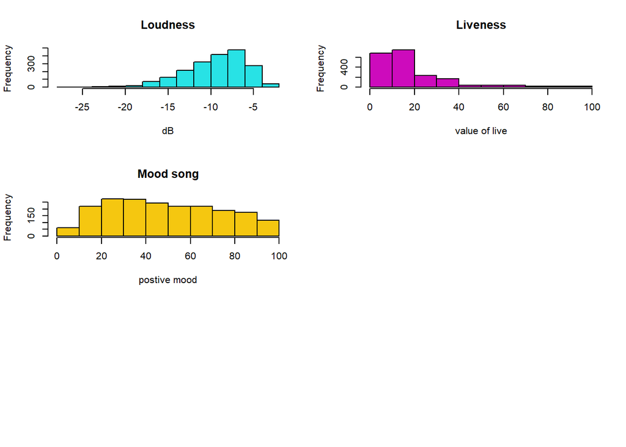

```r
par(mfrow=c(3,2))
hist(Numsongs2$dB, main = "Loudness", xlab = "dB", ylab= "Frequency",col=5)
hist(Numsongs2$Liveness, main = "Liveness", xlab = "value of live", ylab= "Frequency",col=6)
hist(Numsongs2$Valence, main = "Mood song", xlab = "postive mood", ylab= "Frequency",col=7)
```

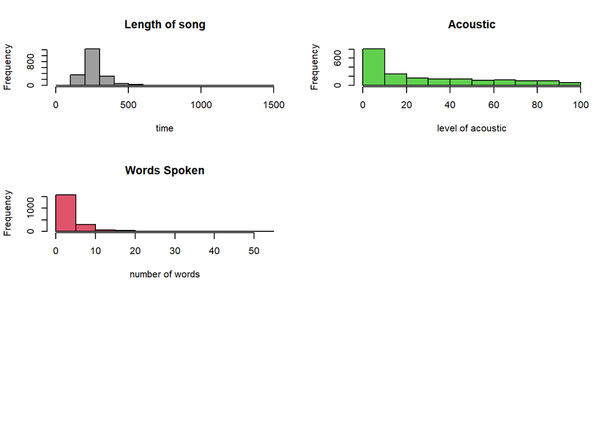

```r
par(mfrow=c(3,2))
hist(Numsongs2$Duration, main = "Length of song", xlab = "time", ylab= "Frequency",col=8)
hist(Numsongs2$Acousticness, main = "Acoustic", xlab = "level of acoustic", ylab= "Frequency",col=11)
hist(Numsongs2$Speechiness, main = "Words Spoken", xlab = "number of words", ylab= "Frequency",col=10)
```

Most of the values for the length of the song histogram are less than 500. This distribution may be normal.The acoustic histogram shows that most values fall from 0 to 20, and all other values are spread evenly.The distribution may be skewed to the right. Words spoken histogram show that almost all of the value falls between 0 and 10.The distribution may be skewed to the right.

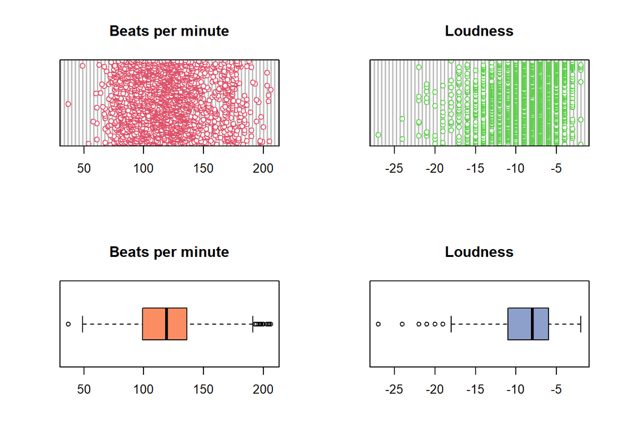

```r
par(mfrow=c(2,2))
dotchart(Numsongs2$BPM, main="Beats per minute", col=2)
dotchart(Numsongs2$dB, main="Loudness", col=3)
boxplot(Numsongs2$BPM, horizontal = TRUE, main="Beats per minute", col=myPalette[2])
boxplot(Numsongs2$dB, horizontal = TRUE, main="Loudness", col=myPalette[3])
```

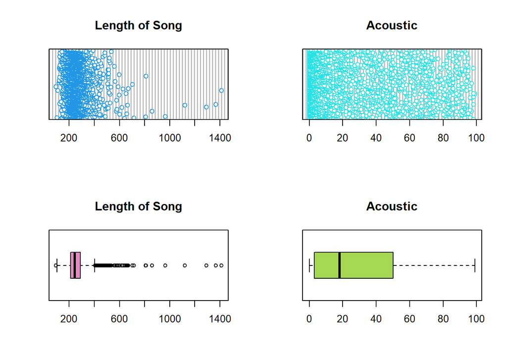

```r
par(mfrow=c(2,2))
dotchart(Numsongs2$Duration, main="Length of Song", col=4)
dotchart(Numsongs2$Acousticness, main="Acoustic", col=5)
boxplot(Numsongs2$Duration, horizontal = TRUE, main="Length of Song", col=myPalette[4])
boxplot(Numsongs2$Acousticness, horizontal = TRUE, main="Acoustic", col=myPalette[5])
```

The dot plot for a song’s length shows a cluster of 200 to 400 with a couple of points outside the cluster. A similar finding is found when looking at the box plot. The box plot shows that the distribution may be normal, with potential outliers mainly occurring after the maximum. The dot plot for an acoustic shows a cluster from 0-20 and even spread after. A similar finding is found when looking at the box plot. The box plot shows that the distribution may be skewed to the right, but there aren’t any potential outliers.

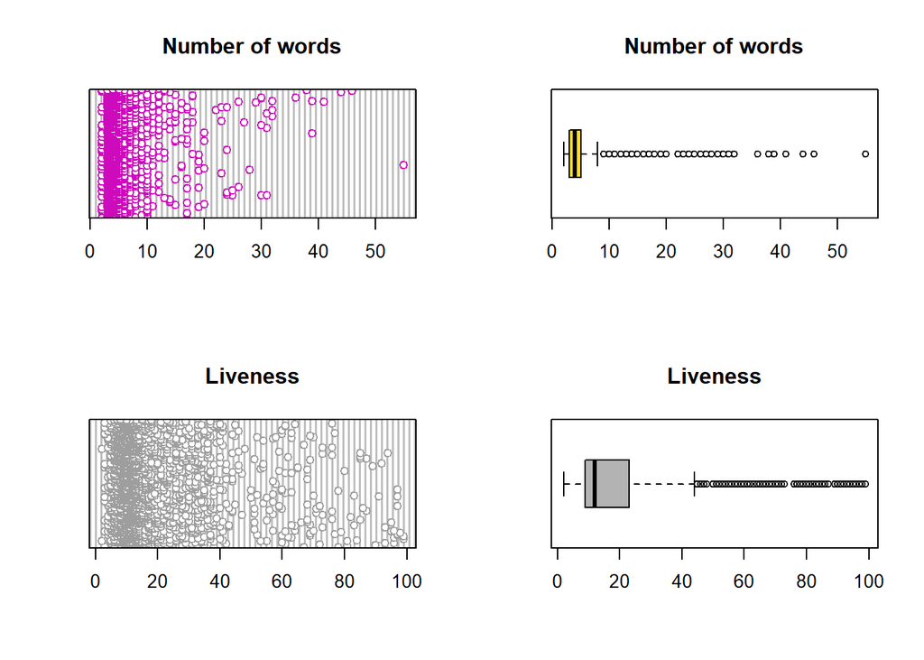

```r
par(mfrow=c(2,2))
dotchart(Numsongs2$Speechiness, main="Number of words", col=6)
boxplot(Numsongs2$Speechiness, horizontal = TRUE, main="Number of words", col=myPalette[6])
dotchart(Numsongs2$Liveness, main="Liveness", col=8)
boxplot(Numsongs2$Liveness, horizontal = TRUE, main="Liveness", col=myPalette[8])
```

The dot plot for the number of words for a song shows a cluster of 0 to 20 with a couple of points outside the cluster. A similar finding is found when looking at the box plot. The box plot shows that the distribution may be normal, with potential outliers mainly occurring after the maximum. The dot plot for liveness shows a cluster from 0-40. A similar finding is found when looking at the box plot. Again, the box plot shows that the distribution may be skewed to the right, with potential outliers occurring after the maximum.

```r
names <- c("BPM","Energy","Danceability","dB","Liveness")
knitr::kable(xtable(summarize(Numsongs2[,names], caption = "Data Summary for Numeric variables in Songs")))
```

|  | N |  | Mean | SD |  | Min | Q1 | Median | Q3 | Max |
| --- | --- | --- | --- | --- | --- | --- | --- | --- | --- | --- |
| BPM | 1994 |  | 120.22 | 28.03 |  | 37 | 99 | 119 | 136 | 206 |
| Energy | 1994 |  | 59.68 | 22.15 |  | 3 | 42 | 61 | 78 | 100 |
| Danceability | 1994 |  | 53.24 | 15.35 |  | 10 | 43 | 53 | 64 | 96 |
| dB | 1994 |  | -9.01 | 3.65 |  | -27 | -11 | -8 | -6 | -2 |
| Liveness | 1994 |  | 19.01 | 16.73 |  | 2 | 9 | 12 | 23 | 99 |

The five-number summary for beats per minute shows that the mean is larger than the median, so the distribution for beats per minute may be slightly skewed to the right. In addition, the maximum and minimum are an outlier for beats per minute because it is smaller than 43.5 and larger than 191.5. The five-number summary for energy shows that the median is larger than the mean, so the distribution for energy may be skewed to the left. Contains no outliers. The five-number summary for dance ability shows that the mean is larger than the median, so the distribution for dance ability may be slightly skewed to the right. In addition, the maximum and minimum are an outlier for dance ability because it is smaller than 11.5 and larger than 95.5. The five-number summary for dB shows that the median is larger than the mean, so the distribution for energy may be skewed to the left. The minimum is an outlier because it is smaller than -18.5.The five-number summary for Liveness shows that the mean is larger than the median so the distribution may be skewed to the right. The maximum is an outlier for the liveness because it is greater than 44.

```r
names <- c("BPM","Energy","Danceability","dB","Liveness","Valence","Duration","Acousticness","Speechiness")
knitr::kable(xtable(summarize(Numsongs2[,names], caption = "Data Summary for Numeric variables in Songs")))
```

|  | N |  | Mean | SD |  | Min | Q1 | Median | Q3 | Max |
| --- | --- | --- | --- | --- | --- | --- | --- | --- | --- | --- |
| BPM | 1994 |  | 120.22 | 28.03 |  | 37 | 99 | 119 | 136 | 206 |
| Energy | 1994 |  | 59.68 | 22.15 |  | 3 | 42 | 61 | 78 | 100 |
| Danceability | 1994 |  | 53.24 | 15.35 |  | 10 | 43 | 53 | 64 | 96 |
| dB | 1994 |  | -9.01 | 3.65 |  | -27 | -11 | -8 | -6 | -2 |
| Liveness | 1994 |  | 19.01 | 16.73 |  | 2 | 9 | 12 | 23 | 99 |
| Valence | 1994 |  | 49.41 | 24.86 |  | 3 | 29 | 47 | 70 | 99 |
| Duration | 1994 |  | 262.44 | 93.60 |  | 93 | 212 | 245 | 289 | 1412 |
| Acousticness | 1994 |  | 28.86 | 29.01 |  | 0 | 3 | 18 | 50 | 99 |
| Speechiness | 1994 |  | 4.99 | 4.40 |  | 2 | 3 | 4 | 5 | 55 |